# The Various Factors That Affect Sleep Patterns

Dhruv Ashok, Kai Magbuhat, Nikhila Suneel

11/14/2022

## Summary Paragraph

The chosen subset of the study comparing sleep to screen time in children contained 29433 observations with 11 variables. The study collected data on a variety of chidren, ranging from age 0 to age 18. While Chart 1 displays the general correlation between sleep time per night and screen time per day, we may observe some general statistics about the distribution of sleep and screen times. The average number of hours spent sleeping every night across children of all sexes and ages is 4.7, and the median is 5. Thus, the sleep distribution is left skewed. In addition, the average number of hours of screen time every day across children of all sexes and ages is 3.08, and the median is 3. Thus, the screen time distribution is right skewed.

## Summary Table

| Age | Average Hours of Sleep | Average Hours of Screen Time |
| --- | --- | --- |
| 0 | 6.14 | 1.27 |
| 1 | 6.10 | 1.54 |
| 2 | 5.87 | 2.24 |
| 3 | 5.46 | 2.53 |
| 4 | 5.03 | 2.64 |
| 5 | 4.84 | 2.73 |
| 6 | 5.03 | 2.65 |
| 7 | 5.18 | 2.71 |
| 8 | 5.07 | 2.80 |
| 9 | 4.94 | 2.94 |
| 10 | 4.83 | 3.07 |
| 11 | 4.66 | 3.19 |
| 12 | 4.52 | 3.33 |
| 13 | 4.39 | 3.55 |
| 14 | 4.22 | 3.62 |
| 15 | 4.07 | 3.75 |
| 16 | 3.89 | 3.83 |
| 17 | 3.73 | 3.81 |
| 18 | 3.68 | 3.86 |

The table is grouped up data included from the screen time vs. sleep dataset. This dataset was chosen because its variables signify correlation between the two main variables, hours of screen time to hours of sleep. We will group by every age in this dataset (1, 2, 3, …, 18). The table displays the calculated mean time of hours spent on screens and the average time of sleep those observed children acquired. We can see a clear pattern: as age increases, the average hours of sleep decreases and the average hours of screen time increases. This can be tied to increased mobile device usage and independence in teenagers compared to younger children, as well as increased external pressures on sleep. There is an interesting correlation to explore here, while also exploring other variables that may be at play here.

## Charts

### Chart 1

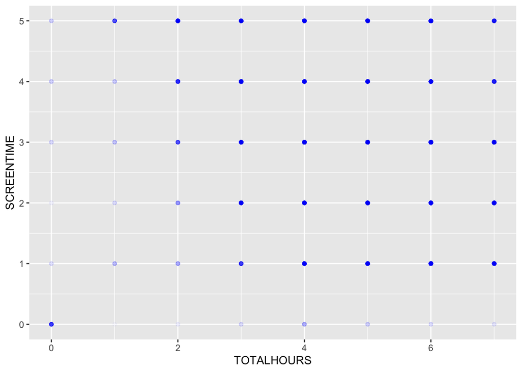

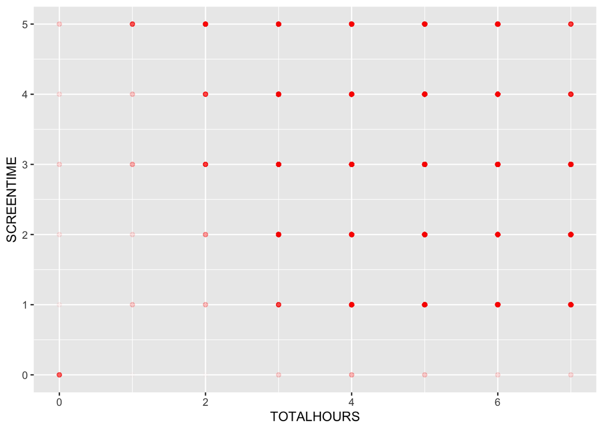

These two scatter plot charts are displayed in two different colors, one blue and one red. The blue represents the male population and red represents the female population. Between the two, this charts looks at the difference between screen time and total hours of sleep. You can observe the differnce of densiities of how many got certain hours of screentime. The darker the dot, the more number of individuals in that range. It can be observed where most of the populaiton lie withing the data. Observations can be made between which gender gets more or less sleep depending on their screen time.

### Chart 2

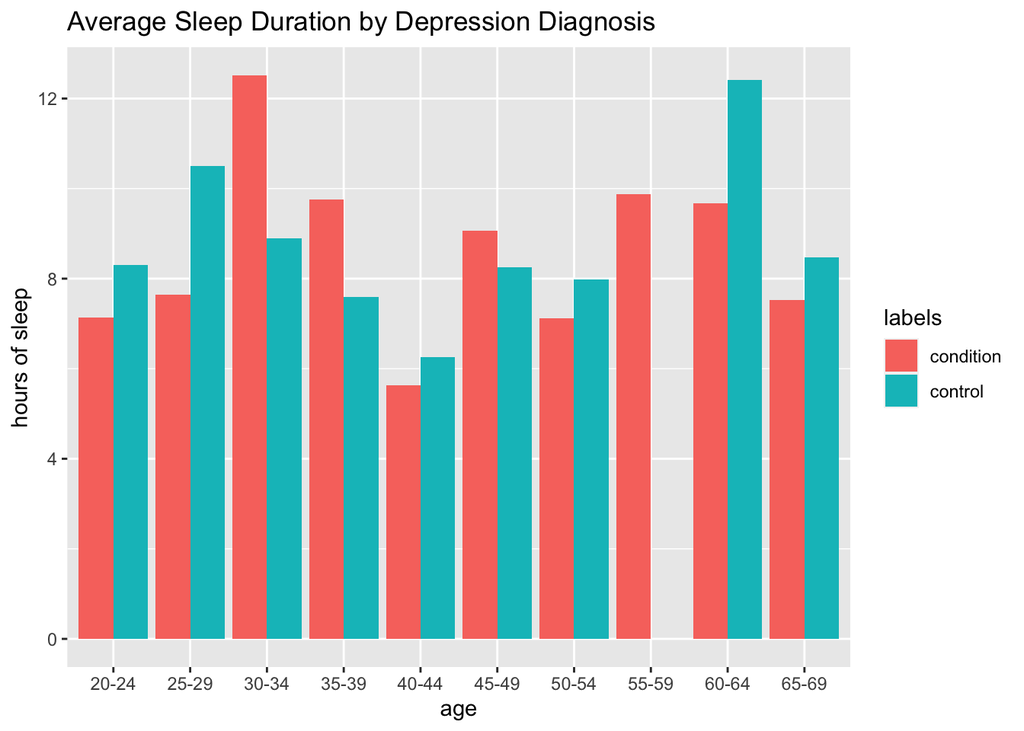

This grouped bar chart compares the average sleep duration in hours, by age group, for patients with a diagnosed form of depression (the condition group) and those without a diagnosed form of depression (the control group). The chart was included to determine if there was a correlation between diagnosed depression and sleep duration. We can observe from the chart that, while not true for every age group in this study, for the *majority* of age groups the condition group gets **less** sleep on average compared to the control group. Further statistical analysis or studies may need to be conducted to determine if this correlation is signficant, and there are some data quality issues as there was no data for the control group for the 55-59 age group. Still, this correlation can certainly be explored further.

### Chart 3

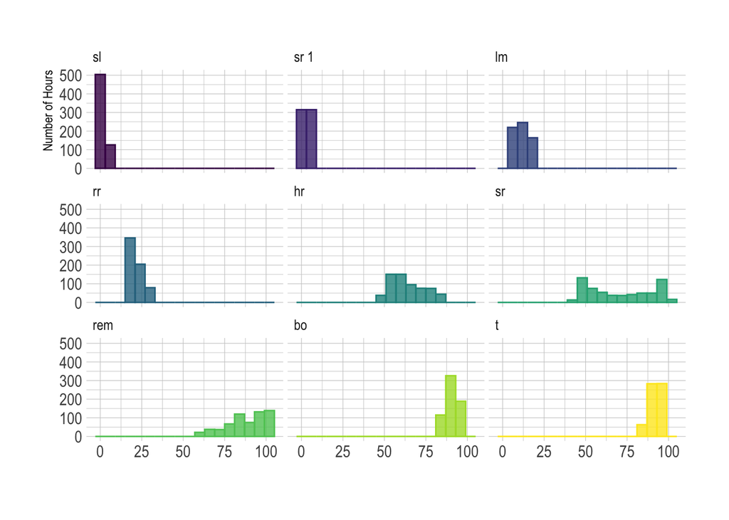